# kaggle_NLP_Disaster Tweets_chatGPT_BERT_upload

대회 사이트  
https://www.kaggle.com/competitions/nlp-getting-started/overview

[figure not shown]

```python
from IPython.display import clear_output
from IPython.display import Image
Image('title.png')
```

1. 대회 과제 (Task)  
   목표: 특정 트윗 텍스트를 분석하여, 이 트윗이 실제 재난(화재, 지진, 사고 등) 상황을 묘사하고 있는지(Real Disaster) 아니면 단순히 비유나 일상적인 대화에서 재난 단어를 사용한 것인지(Not Disaster)를 이진 분류(Binary Classification)하는 것이다.  
   평가 지표: 모델의 성능은 F1-Score로 평가된다. 이는 정밀도(Precision)와 재현율(Recall)의 조화 평균으로, 클래스 불균형이 있을 수 있는 분류 문제에서 흔히 사용된다.
2. 데이터 구성 (Dataset Features)  
   데이터셋은 CSV 파일 형태로 제공되며, 주요 칼럼은 다음과 같다:  
   id: 각 트윗의 고유 식별자  
   text: 트윗의 실제 본문 내용  
   keyword: 트윗에서 추출된 특정 키워드  
   location: 트윗이 발신된 위치 정보. 사용자가 직접 입력하는 값이기에 형식이 일정하지 않고 'dirty'한 데이터가 많다.  
   target: (학습 데이터에만 존재) 실제 재난인 경우 1, 아닌 경우 0으로 표시된다.

전체 참가팀 656 중 154위이다.

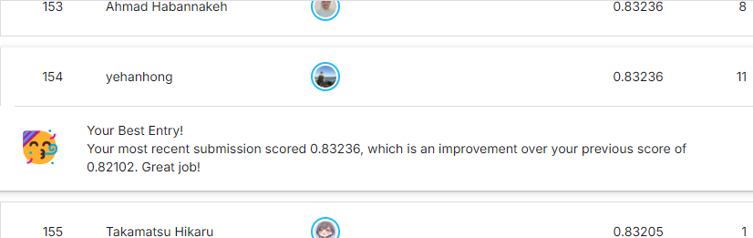

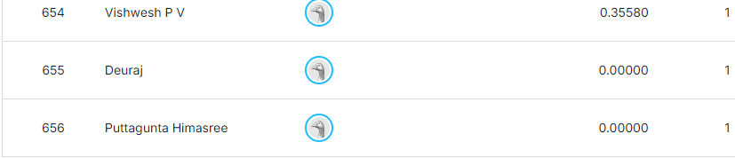

```python
import numpy as np
import pandas as pd
import torch
import torch.nn as nn

from torch.utils.data import DataLoader, TensorDataset
from transformers import (
    BertTokenizer,
    BertForSequenceClassification,
    AdamW,
    get_linear_schedule_with_warmup
)

from sklearn.model_selection import train_test_split
from sklearn.metrics import f1_score

from pytictoc import TicToc
import datetime
```

```python
SEED = 33
```

#### 데이터 로드

```python
DATA = './data'
```

```python
train_df = pd.read_csv(os.path.join(DATA, 'train.csv'))
test_df = pd.read_csv(os.path.join(DATA, 'test.csv'))
```

```python
train_df.head()
```

|  | id | keyword | location | text | target |
| --- | --- | --- | --- | --- | --- |
| 0 | 1 | NaN | NaN | Our Deeds are the Reason of this #earthquake M... | 1 |
| 1 | 4 | NaN | NaN | Forest fire near La Ronge Sask. Canada | 1 |
| 2 | 5 | NaN | NaN | All residents asked to 'shelter in place' are ... | 1 |
| 3 | 6 | NaN | NaN | 13,000 people receive #wildfires evacuation or... | 1 |
| 4 | 7 | NaN | NaN | Just got sent this photo from Ruby #Alaska as ... | 1 |

```python
texts = train_df["text"].values
labels = train_df["target"].values
```

Train / Validation 분리

```python
X_train, X_val, y_train, y_val = train_test_split(
    texts,
    labels,
    test_size=0.2,
    random_state=42,
    stratify=labels
)
```

```python
MODEL_NAME = "bert-base-uncased"
MAX_LEN = 128
BATCH_SIZE = 32
EPOCHS = 3
LR = 2e-5
```

BERT Tokenizer

```python
tokenizer = BertTokenizer.from_pretrained(MODEL_NAME)
```

텍스트 → BERT 입력 텐서 변환 함수

```python
def encode_texts(texts, tokenizer, max_len):
    encoding = tokenizer(
        list(texts),
        padding=True,
        truncation=True,
        max_length=max_len,
        return_tensors="pt"
    )
    return encoding["input_ids"], encoding["attention_mask"]
```

Train / Validation 텐서 생성

```python
train_input_ids, train_attention_masks = encode_texts(
    X_train, tokenizer, MAX_LEN
)
val_input_ids, val_attention_masks = encode_texts(
    X_val, tokenizer, MAX_LEN
)

train_labels = torch.tensor(y_train, dtype=torch.long)
val_labels = torch.tensor(y_val, dtype=torch.long)
```

TensorDataset & DataLoader 생성

```python
train_dataset = TensorDataset(
    train_input_ids,
    train_attention_masks,
    train_labels
)

val_dataset = TensorDataset(
    val_input_ids,
    val_attention_masks,
    val_labels
)

train_loader = DataLoader(
    train_dataset,
    batch_size=BATCH_SIZE,
    shuffle=True
)

val_loader = DataLoader(
    val_dataset,
    batch_size=BATCH_SIZE,
    shuffle=False
)
```

BERT 모델

```python
device = torch.device("cuda" if torch.cuda.is_available() else "cpu")
```

```python
model = BertForSequenceClassification.from_pretrained(
    MODEL_NAME,
    num_labels=2
)

model.to(device)
```

```
Some weights of BertForSequenceClassification were not initialized from the model checkpoint at bert-base-uncased and are newly initialized: ['classifier.weight', 'classifier.bias']
You should probably TRAIN this model on a down-stream task to be able to use it for predictions and inference.
```

[output not shown]

Optimizer & Scheduler

```python
optimizer = AdamW(model.parameters(), lr=LR)

total_steps = len(train_loader) * EPOCHS

scheduler = get_linear_schedule_with_warmup(
    optimizer,
    num_warmup_steps=0,
    num_training_steps=total_steps
)
```

학습 함수

```python
def train_one_epoch(model, dataloader):
    model.train()
    total_loss = 0

    for batch in dataloader:
        input_ids, attention_mask, labels = [b.to(device) for b in batch]

        outputs = model(
            input_ids=input_ids,
            attention_mask=attention_mask,
            labels=labels
        )

        loss = outputs.loss
        total_loss += loss.item()

        loss.backward()
        optimizer.step()
        scheduler.step()
        optimizer.zero_grad()

    return total_loss / len(dataloader)
```

검증 + best threshold 탐색 함수

```python
def evaluate(model, dataloader):
    model.eval()
    probs = []
    true_labels = []

    with torch.no_grad():
        for batch in dataloader:
            input_ids, attention_mask, labels = [b.to(device) for b in batch]

            outputs = model(
                input_ids=input_ids,
                attention_mask=attention_mask
            )

            logits = outputs.logits
            prob = torch.softmax(logits, dim=1)[:, 1]

            probs.extend(prob.cpu().numpy())
            true_labels.extend(labels.cpu().numpy())

    return np.array(probs), np.array(true_labels)
```

best threshold 계산

```python
def find_best_threshold(y_true, y_prob):
    best_th = 0.5
    best_f1 = 0

    for th in np.arange(0.1, 0.9, 0.01):
        y_pred = (y_prob >= th).astype(int)
        f1 = f1_score(y_true, y_pred)

        if f1 > best_f1:
            best_f1 = f1
            best_th = th

    return best_th, best_f1
```

전체 학습 루프

```python
time = TicToc()
time.tic()

for epoch in range(EPOCHS):
    train_loss = train_one_epoch(model, train_loader)

    val_probs, val_labels = evaluate(model, val_loader)
    best_th, best_f1 = find_best_threshold(val_labels, val_probs)

    print(f"[Epoch {epoch+1}]")
    print(f"Train Loss: {train_loss:.4f}")
    print(f"Best F1: {best_f1:.4f}, Best Threshold: {best_th:.2f}")

time.toc()
```

```
[Epoch 1]
Train Loss: 0.4664
Best F1: 0.8248, Best Threshold: 0.54
[Epoch 2]
Train Loss: 0.3337
Best F1: 0.8238, Best Threshold: 0.63
[Epoch 3]
Train Loss: 0.2688
Best F1: 0.8198, Best Threshold: 0.61
Elapsed time is 191.586843 seconds.
```

테스트 데이터 적합

```python
test_texts = test_df["text"].values
```

Test 텍스트 토큰화 (기존 함수 재사용)

```python
test_input_ids, test_attention_masks = encode_texts(
    test_texts, tokenizer, MAX_LEN
)
```

TensorDataset & DataLoader 생성

```python
test_dataset = TensorDataset(
    test_input_ids,
    test_attention_masks
)

test_loader = DataLoader(
    test_dataset,
    batch_size=BATCH_SIZE,
    shuffle=False
)
```

Test 데이터 확률 예측

```python
def predict(model, dataloader):
    model.eval()
    probs = []

    with torch.no_grad():
        for batch in dataloader:
            input_ids, attention_mask = [b.to(device) for b in batch]

            outputs = model(
                input_ids=input_ids,
                attention_mask=attention_mask
            )

            logits = outputs.logits
            prob = torch.softmax(logits, dim=1)[:, 1]
            probs.extend(prob.cpu().numpy())

    return np.array(probs)
```

```python
test_probs = predict(model, test_loader)
```

best threshold 적용 (Validation에서 찾은 값)

```python
test_preds = (test_probs >= best_th).astype(int)
```

```python
test_preds
```

```
array([1, 1, 1, ..., 1, 1, 1])
```